# Assignment_9

# Load Packages

```r
library(tidyverse)
library(easystats)
library(GGally)
library(MASS)
```

# Read-In Data

```r
grad_df <- read.csv("GradSchool_Admissions.csv")
```

# Explorations

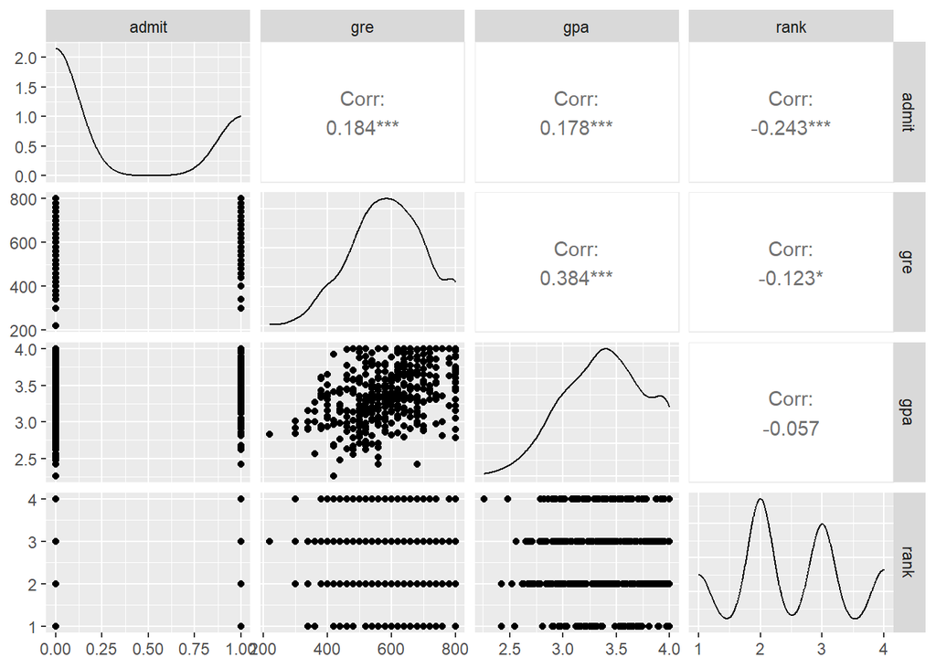

```r
View(grad_df)
grad_df %>%
  ggpairs()
```

Based on the correlation matrices, it looks like no single variable affects admission more than the others. The most useful plot appears to show a positive relationship between GPA and GRE scores, though.

Let’s make some models now. I’ll start with the most simple ones. Since our dependent variable is binary, I need to account for that in my models using family = ‘binomial’.

```r
gpa_mod <- glm(data = grad_df,
               formula = admit ~ gpa,
               family = 'binomial')
summary(gpa_mod)
```

```
##
## Call:
## glm(formula = admit ~ gpa, family = "binomial", data = grad_df)
##
## Coefficients:
##             Estimate Std. Error z value Pr(>|z|)
## (Intercept)  -4.3576     1.0353  -4.209 2.57e-05 ***
## gpa           1.0511     0.2989   3.517 0.000437 ***
## ---
## Signif. codes:  0 '***' 0.001 '**' 0.01 '*' 0.05 '.' 0.1 ' ' 1
##
## (Dispersion parameter for binomial family taken to be 1)
##
##     Null deviance: 499.98  on 399  degrees of freedom
## Residual deviance: 486.97  on 398  degrees of freedom
## AIC: 490.97
##
## Number of Fisher Scoring iterations: 4
```

```r
gre_mod <- glm(data = grad_df,
               formula = admit ~ gre,
               family = 'binomial')
summary(gre_mod)
```

```
##
## Call:
## glm(formula = admit ~ gre, family = "binomial", data = grad_df)
##
## Coefficients:
##              Estimate Std. Error z value Pr(>|z|)
## (Intercept) -2.901344   0.606038  -4.787 1.69e-06 ***
## gre          0.003582   0.000986   3.633  0.00028 ***
## ---
## Signif. codes:  0 '***' 0.001 '**' 0.01 '*' 0.05 '.' 0.1 ' ' 1
##
## (Dispersion parameter for binomial family taken to be 1)
##
##     Null deviance: 499.98  on 399  degrees of freedom
## Residual deviance: 486.06  on 398  degrees of freedom
## AIC: 490.06
##
## Number of Fisher Scoring iterations: 4
```

```r
rank_mod <- glm(data = grad_df,
               formula = admit ~ rank,
               family = 'binomial')
summary(rank_mod)
```

```
##
## Call:
## glm(formula = admit ~ rank, family = "binomial", data = grad_df)
##
## Coefficients:
##             Estimate Std. Error z value Pr(>|z|)
## (Intercept)   0.6366     0.3061   2.080   0.0375 *
## rank         -0.5863     0.1240  -4.728 2.26e-06 ***
## ---
## Signif. codes:  0 '***' 0.001 '**' 0.01 '*' 0.05 '.' 0.1 ' ' 1
##
## (Dispersion parameter for binomial family taken to be 1)
##
##     Null deviance: 499.98  on 399  degrees of freedom
## Residual deviance: 475.71  on 398  degrees of freedom
## AIC: 479.71
##
## Number of Fisher Scoring iterations: 4
```

Alright, so they all show that there is a very significant relationship (low p-value). Now to try some different variable combinations. Typically, including the interactions between two independent variables makes a better model, so I’ll focus on that.

```r
gpa_gre_mod <- glm(data = grad_df,
               formula = admit ~ gpa * gre,
               family = 'binomial')
summary(gpa_gre_mod)
```

```
##
## Call:
## glm(formula = admit ~ gpa * gre, family = "binomial", data = grad_df)
##
## Coefficients:
##               Estimate Std. Error z value Pr(>|z|)
## (Intercept) -13.818700   5.874816  -2.352   0.0187 *
## gpa           3.367918   1.722685   1.955   0.0506 .
## gre           0.017464   0.009606   1.818   0.0691 .
## gpa:gre      -0.004327   0.002787  -1.552   0.1205
## ---
## Signif. codes:  0 '***' 0.001 '**' 0.01 '*' 0.05 '.' 0.1 ' ' 1
##
## (Dispersion parameter for binomial family taken to be 1)
##
##     Null deviance: 499.98  on 399  degrees of freedom
## Residual deviance: 477.85  on 396  degrees of freedom
## AIC: 485.85
##
## Number of Fisher Scoring iterations: 4
```

```r
gpa_rank_mod <-glm(data = grad_df,
               formula = admit ~ gpa * rank,
               family = 'binomial')
summary(gpa_rank_mod)
```

```
##
## Call:
## glm(formula = admit ~ gpa * rank, family = "binomial", data = grad_df)
##
## Coefficients:
##             Estimate Std. Error z value Pr(>|z|)
## (Intercept)  -3.7164     2.9443  -1.262    0.207
## gpa           1.2697     0.8532   1.488    0.137
## rank         -0.2171     1.1994  -0.181    0.856
## gpa:rank     -0.1062     0.3472  -0.306    0.760
##
## (Dispersion parameter for binomial family taken to be 1)
##
##     Null deviance: 499.98  on 399  degrees of freedom
## Residual deviance: 463.84  on 396  degrees of freedom
## AIC: 471.84
##
## Number of Fisher Scoring iterations: 4
```

```r
gre_rank_mod <- glm(data = grad_df,
               formula = admit ~ gre * rank,
               family = 'binomial')
summary(gre_rank_mod)
```

```
##
## Call:
## glm(formula = admit ~ gre * rank, family = "binomial", data = grad_df)
##
## Coefficients:
##               Estimate Std. Error z value Pr(>|z|)
## (Intercept) -1.356e+00  1.687e+00  -0.804    0.421
## gre          3.210e-03  2.732e-03   1.175    0.240
## rank        -5.581e-01  6.712e-01  -0.832    0.406
## gre:rank     7.911e-06  1.091e-03   0.007    0.994
##
## (Dispersion parameter for binomial family taken to be 1)
##
##     Null deviance: 499.98  on 399  degrees of freedom
## Residual deviance: 465.20  on 396  degrees of freedom
## AIC: 473.2
##
## Number of Fisher Scoring iterations: 4
```

Interesting, so the significance actually decreases (p-value increases) with these models. Now I’ll try using MASS to find the “best” model.

```r
mod_all <- glm(dat = grad_df,
                     formula = admit ~ gpa * gre * rank,
               family = 'binomial')
best_mod = stepAIC(mod_all)
```

```
## Start:  AIC=472.25
## admit ~ gpa * gre * rank
##
##                Df Deviance    AIC
## - gpa:gre:rank  1   456.25 470.25
## <none>              456.25 472.25
##
## Step:  AIC=470.25
## admit ~ gpa + gre + rank + gpa:gre + gpa:rank + gre:rank
##
##            Df Deviance    AIC
## - gre:rank  1   456.34 468.34
## - gpa:rank  1   456.58 468.58
## <none>          456.25 470.25
## - gpa:gre   1   459.31 471.31
##
## Step:  AIC=468.34
## admit ~ gpa + gre + rank + gpa:gre + gpa:rank
##
##            Df Deviance    AIC
## - gpa:rank  1   456.60 466.60
## <none>          456.34 468.34
## - gpa:gre   1   459.33 469.33
##
## Step:  AIC=466.6
## admit ~ gpa + gre + rank + gpa:gre
##
##           Df Deviance    AIC
## <none>         456.60 466.60
## - gpa:gre  1   459.44 467.44
## - rank     1   477.85 485.85
```

```r
best_mod$formula
```

```
## admit ~ gpa + gre + rank + gpa:gre
```

Sure enough, the “best” model accounts for all of the variables separately, but takes into account the interaction between GRE scores and GPA. Now I will compare the models to see if our “best” model is “perfect”, while still including the interactions models for extra verification.

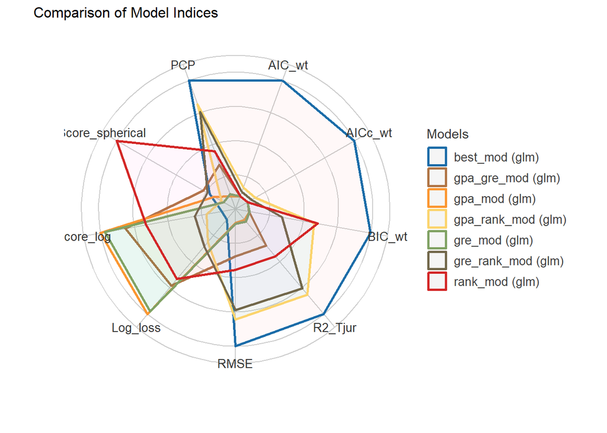

```r
compare_performance(best_mod, gpa_mod, gre_mod, rank_mod,
                    gpa_gre_mod, gpa_rank_mod, gre_rank_mod) %>% plot()
```

It looks like the “best” model isn’t “perfect” after all. Now I want to see how accurate it is (how often does it correctly predict admission).

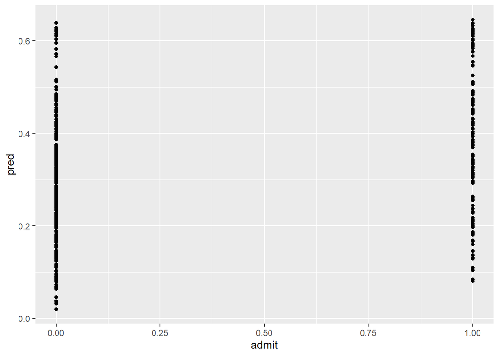

```r
grad_df$pred = predict(best_mod, grad_df, type = 'response')
View(grad_df)
grad_df %>%
  ggplot(aes(x = admit,
             y = pred)) +
  geom_point()
```

This plot was supposed to give me a good dividing line to know what prediction values indicate acceptance or rejection, but it’s kind of hard to find a clear divide. It looks like no one prediction score about 0.075 was admitted, so we’ll use that as our dividing line.

```r
grad_df = grad_df %>%
  mutate(outcome = case_when(pred > 0.075 ~ 'Accept',
                             pred < 0.075 ~ 'Reject',
                             TRUE ~ 'Not sure')) %>%
  mutate(compare = case_when(admit == 0 & outcome == 'Reject' ~ 'Correct',
                             admit == 1 & outcome == 'Accept' ~ 'Correct',
                             TRUE ~ 'Not correct'))
View(grad_df)
table(grad_df$outcome)
```

```
##
## Accept Reject
##    389     11
```

```r
table(grad_df$compare)
```

```
##
##     Correct Not correct
##         138         262
```

The accuracy of the model with these prediction parameters can be calculated by dividing the number of correct predictions by the number of total predictions. Therefore, 138/400 = 0.345, meaning my model can only correctly predict grad school admission 34.5% of the time.

# Conclusions

Even though a model may sound really promising, it might not be the most accurate when compared with actual data. In the future, I would like to do see if there are other factors that could also affect graduate school admissions, such as essay scores or research opportunities. This information may help me create a better model that has a higher percentage of accurate predictions.